# Data Science as Field NYPD

2024-09-26

## Introduction

This analysis will work with data from City of New York about historical shooting incidents reported to the NYPD. The data can be found [here](https://data.cityofnewyork.us/api/views/833y-fsy8/rows.csv).

Some of the features of the data are the date and time of the shooting, the borough with additional location details, as well as some demographic data on the victim and perpetrator if available.

The below code snippet is to load and handle some minor data cleaning. The output from the cell will also provide a high-level summary of the loaded data frame.

```r
nypd_url = "https://data.cityofnewyork.us/api/views/833y-fsy8/rows.csv"
df_nypd = read.csv(nypd_url)
# want to convert columns
# dates to date type
# strings to factors where appropriate
# Check for missing data
df_nypd_clean = df_nypd %>%
  # select only required columns
  select(c("INCIDENT_KEY", "OCCUR_DATE", "OCCUR_TIME", "BORO", "LOC_OF_OCCUR_DESC", "STATISTICAL_MURDER_FLAG",
           "PERP_AGE_GROUP", "PERP_SEX", "PERP_RACE",
           "VIC_AGE_GROUP", "VIC_SEX", "VIC_RACE",
           )
         ) %>%
  # convert data types
  mutate(OCCUR_DATE = as_date(OCCUR_DATE, format="%m/%d/%Y"),
                              OCCUR_DATETIME = as_datetime(paste(OCCUR_DATE, OCCUR_TIME)),
                              OCCUR_YEAR = year(OCCUR_DATE),
                              OCCUR_MONTH = month(OCCUR_DATE),
                              OCCUR_HOUR = hour(OCCUR_DATETIME),
                              OCCUR_DOW = factor(weekdays(OCCUR_DATE),
                                                 levels=c("Sunday", "Monday", "Tuesday", "Wednesday",
                                                          "Thursday", "Friday", "Saturday"),
                                                 ordered=TRUE),
                                   # Location details
                              BORO = as.factor(BORO),
                              LOC_OF_OCCUR_DESC = as.factor(LOC_OF_OCCUR_DESC),
                              #LOC_CLASSFCTN_DESC = as.factor(LOC_CLASSFCTN_DESC),
                              #LOCATION_DESC = as.factor(LOCATION_DESC),
                              # Perp details
                              PERP_AGE_GROUP = as.factor(PERP_AGE_GROUP),
                              PERP_SEX = as.factor(PERP_SEX),
                              PERP_RACE = as.factor(PERP_RACE),
                              # Victim details
                              VIC_AGE_GROUP = as.factor(VIC_AGE_GROUP),
                              VIC_SEX = as.factor(VIC_SEX),
                              VIC_RACE = as.factor(VIC_RACE),

                              STATISTICAL_MURDER_FLAG = as.logical(STATISTICAL_MURDER_FLAG)
                              )

summary(df_nypd_clean)
```

```
##   INCIDENT_KEY         OCCUR_DATE          OCCUR_TIME
##  Min.   :  9953245   Min.   :2006-01-01   Length:28562
##  1st Qu.: 65439914   1st Qu.:2009-09-04   Class :character
##  Median : 92711254   Median :2013-09-20   Mode  :character
##  Mean   :127405824   Mean   :2014-06-07
##  3rd Qu.:203131993   3rd Qu.:2019-09-29
##  Max.   :279758069   Max.   :2023-12-29
##
##             BORO       LOC_OF_OCCUR_DESC STATISTICAL_MURDER_FLAG PERP_AGE_GROUP
##  BRONX        : 8376          :25596     Mode :logical                  :9344
##  BROOKLYN     :11346   INSIDE :  460     FALSE:23036             18-24  :6438
##  MANHATTAN    : 3762   OUTSIDE: 2506     TRUE :5526              25-44  :6041
##  QUEENS       : 4271                                             UNKNOWN:3148
##  STATEN ISLAND:  807                                             <18    :1682
##                                                                  (null) :1141
##                                                                  (Other): 768
##    PERP_SEX              PERP_RACE     VIC_AGE_GROUP   VIC_SEX
##        : 9310   BLACK         :11903   <18    : 2954   F: 2760
##  (null): 1141                 : 9310   1022   :    1   M:25790
##  F     :  444   WHITE HISPANIC: 2510   18-24  :10384   U:   12
##  M     :16168   UNKNOWN       : 1837   25-44  :12973
##  U     : 1499   BLACK HISPANIC: 1392   45-64  : 1981
##                 (null)        : 1141   65+    :  205
##                 (Other)       :  469   UNKNOWN:   64
##                            VIC_RACE     OCCUR_DATETIME
##  AMERICAN INDIAN/ALASKAN NATIVE:   11   Min.   :2006-01-01 02:00:00.00
##  ASIAN / PACIFIC ISLANDER      :  440   1st Qu.:2009-09-04 07:15:00.00
##  BLACK                         :20235   Median :2013-09-20 17:56:00.00
##  BLACK HISPANIC                : 2795   Mean   :2014-06-07 19:48:01.81
##  UNKNOWN                       :   70   3rd Qu.:2019-09-30 10:10:30.00
##  WHITE                         :  728   Max.   :2023-12-29 21:22:00.00
##  WHITE HISPANIC                : 4283
##    OCCUR_YEAR    OCCUR_MONTH       OCCUR_HOUR        OCCUR_DOW
##  Min.   :2006   Min.   : 1.000   Min.   : 0.00   Sunday   :5669
##  1st Qu.:2009   1st Qu.: 5.000   1st Qu.: 3.00   Monday   :4062
##  Median :2013   Median : 7.000   Median :15.00   Tuesday  :3331
##  Mean   :2014   Mean   : 6.805   Mean   :12.27   Wednesday:3145
##  3rd Qu.:2019   3rd Qu.: 9.000   3rd Qu.:20.00   Thursday :3169
##  Max.   :2023   Max.   :12.000   Max.   :23.00   Friday   :3759
##                                                  Saturday :5427
```

## Shootings by Borough

An initial thing to consider is which boroughs have the most shootings. We can see in the below bar chart Brooklyn has the highest number of shootings. This is not too suprising as Brooklyn has the largest population amonst the 5 boroughs from the 2020 census.

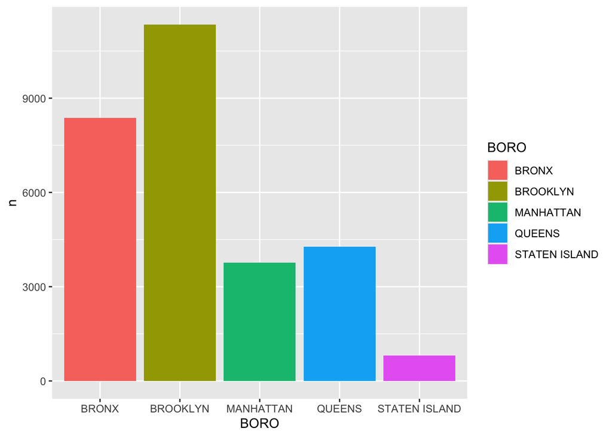

```r
df_nypd_clean %>%
  group_by(BORO) %>%
  count() %>%
  ggplot(aes(x=BORO, y=n)) + geom_bar(stat="identity", aes(fill=BORO))
```

## Shootings Over the Years

Our data covers the years 2006 to 2023. We can see the number of shootings is decreasing significantly until 202 where we see a big spike after which it starts to fall again. The plot includes a line chart by borough along with a fitted line for each covering the range of 2006 to 2019.

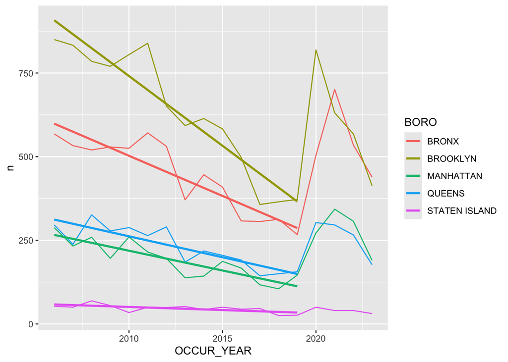

```r
df_nypd_year_cnt = df_nypd_clean %>%
  group_by(BORO, OCCUR_YEAR) %>%
  count()

ggplot(df_nypd_year_cnt, aes(x=OCCUR_YEAR, y=n, colour=BORO)) +
  geom_line(data=df_nypd_year_cnt) +
  geom_smooth(data=subset(df_nypd_year_cnt, OCCUR_YEAR <= 2019), method='lm', formula=y~x, se=F)
```

## Shootings by Day of Week and Time of Day

Based on the below scatter plots we can see weekends and late nights are when most shootings occur.

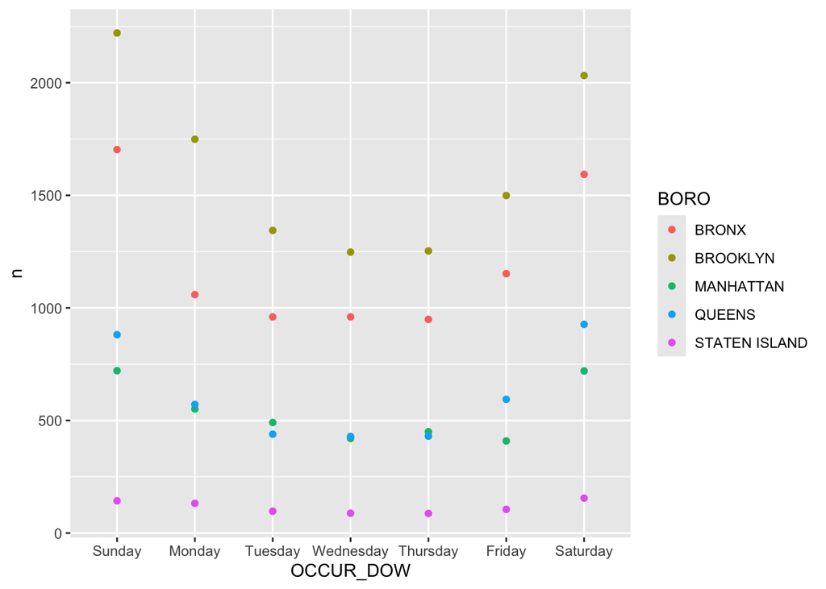

```r
df_nypd_clean %>%
  group_by(BORO, OCCUR_DOW) %>%
  count() %>%
  ggplot(aes(x=OCCUR_DOW, y=n)) + geom_point(aes(color=BORO))
```

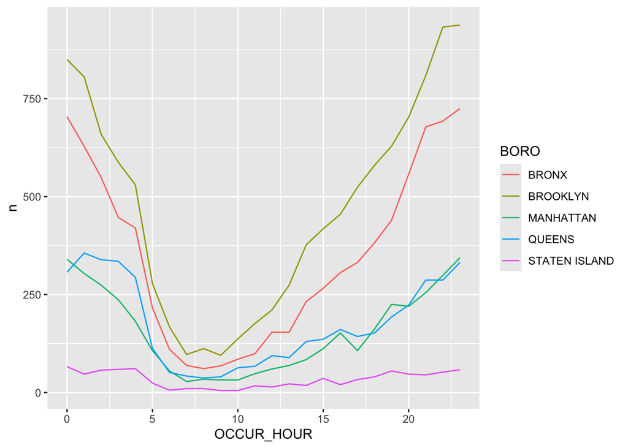

```r
df_nypd_clean %>%
  group_by(BORO, OCCUR_HOUR) %>%
  count() %>%
  ggplot(aes(x=OCCUR_HOUR, y=n)) + geom_line(aes(color=BORO))
```

## Bias Discussion

From the above analysis, we can see when and where (at a high level) shootings occur in NYC. Some things that may have biased our analysis is the drastically differing sizes of the boroughs, both in size and land area. We may see differing statistics if we were to scale the counts of shootings to instead be per some unit of population to help understand rate metrics. Because if we have more people, there is generally a higher likelihood of there being a shooting. We also are only considering the high level view of boroughs, but each of the 5 boroughs have a diverse variety of neighborhoods with different demographics that can factor into higher rates of shootings.